# Mini-Lab_Feb11

Contributors

- Tadd Backus
- Kendall Scott
- Austin Webb
- Milan Patel

```python
from IPython.display import HTML
HTML('''<script>
code_show_err=false;
function code_toggle_err() {
 if (code_show_err){
 $('div.output_stderr').hide();
 } else {
 $('div.output_stderr').show();
 }
 code_show_err = !code_show_err
}
$( document ).ready(code_toggle_err);
</script>
To toggle on/off output_stderr, click <a href="javascript:code_toggle_err()">here</a>.''')
```

To toggle on/off output_stderr, click here.

```python
import pandas as pd
import io
import numpy as np
import matplotlib.pyplot as plt
import seaborn as sns
from sklearn.model_selection import ShuffleSplit
from sklearn.linear_model import LogisticRegression
from sklearn import metrics as mt
from sklearn.preprocessing import StandardScaler
from sklearn.svm import SVC
from sklearn.model_selection import StratifiedShuffleSplit
from sklearn.linear_model import SGDClassifier

pd.set_option('display.max_columns',None)

import warnings
warnings.filterwarnings('ignore')
```

```python
forest_cover_type = pd.read_csv('covtype.csv')
forest_cover_type.head()
# Creating a new dataset that only contains the most common cover types
#updated to all
# Renaming wilderness areas
forestDF = forest_cover_type
forestDF.rename(columns={'Wilderness_Area1':'Rawah','Wilderness_Area2':'Neota','Wilderness_Area3':'Comanche Peak','Wilderness_Area4':'Cache la Poudre'},inplace=True)
forestDF.head()


# Coding Lodgepole Pine as 1 and Spruce/Fir as 0
```

|  | Elevation | Aspect | Slope | Horizontal_Distance_To_Hydrology | Vertical_Distance_To_Hydrology | Horizontal_Distance_To_Roadways | Hillshade_9am | Hillshade_Noon | Hillshade_3pm | Horizontal_Distance_To_Fire_Points | Rawah | Neota | Comanche Peak | Cache la Poudre | Soil_Type1 | Soil_Type2 | Soil_Type3 | Soil_Type4 | Soil_Type5 | Soil_Type6 | Soil_Type7 | Soil_Type8 | Soil_Type9 | Soil_Type10 | Soil_Type11 | Soil_Type12 | Soil_Type13 | Soil_Type14 | Soil_Type15 | … |
| --- | --- | --- | --- | --- | --- | --- | --- | --- | --- | --- | --- | --- | --- | --- | --- | --- | --- | --- | --- | --- | --- | --- | --- | --- | --- | --- | --- | --- | --- | --- |
| 0 | 2596 | 51 | 3 | 258 | 0 | 510 | 221 | 232 | 148 | 6279 | 1 | 0 | 0 | 0 | 0 | 0 | 0 | 0 | 0 | 0 | 0 | 0 | 0 | 0 | 0 | 0 | 0 | 0 | 0 | … |
| 1 | 2590 | 56 | 2 | 212 | -6 | 390 | 220 | 235 | 151 | 6225 | 1 | 0 | 0 | 0 | 0 | 0 | 0 | 0 | 0 | 0 | 0 | 0 | 0 | 0 | 0 | 0 | 0 | 0 | 0 | … |
| 2 | 2804 | 139 | 9 | 268 | 65 | 3180 | 234 | 238 | 135 | 6121 | 1 | 0 | 0 | 0 | 0 | 0 | 0 | 0 | 0 | 0 | 0 | 0 | 0 | 0 | 0 | 1 | 0 | 0 | 0 | … |
| 3 | 2785 | 155 | 18 | 242 | 118 | 3090 | 238 | 238 | 122 | 6211 | 1 | 0 | 0 | 0 | 0 | 0 | 0 | 0 | 0 | 0 | 0 | 0 | 0 | 0 | 0 | 0 | 0 | 0 | 0 | … |
| 4 | 2595 | 45 | 2 | 153 | -1 | 391 | 220 | 234 | 150 | 6172 | 1 | 0 | 0 | 0 | 0 | 0 | 0 | 0 | 0 | 0 | 0 | 0 | 0 | 0 | 0 | 0 | 0 | 0 | 0 | … |

```python
#New dataframe that only contains two most common cover types
# 1 -> Spruce/Fir
# 2 -> Lodgepole Pine

forestDF = forest_cover_type[(forest_cover_type['Cover_Type']==1) | (forest_cover_type['Cover_Type']==2)]
```

```python
forestDF = forestDF.astype({'Cover_Type':'string'})
forestDF['Cover_Type'] = forestDF['Cover_Type'].str.replace('1','Spruce/Fir')
forestDF['Cover_Type'] = forestDF['Cover_Type'].str.replace('2','Lodgepole Pine')
forestDF['Cover_Type'].describe().transpose()
```

```
count             495141
unique                 2
top       Lodgepole Pine
freq              283301
Name: Cover_Type, dtype: object
```

```python
# Lodgepole Pine = 1 | Spruce/Fir = 0
forestDF['treeType'] = forestDF.Cover_Type == 'Lodgepole Pine'
forestDF.treeType = forestDF.treeType.astype(np.int64)
if 'Cover_Type' in forestDF:
    del forestDF['Cover_Type']
```

```python
forestFullDF = forestDF.copy()
```

## Create Models

For our models, we decided to predict if a certain land plot is Spruce/Fir or Lodegpole Pine.

# Quick Model run through

The following sections create and train two models on the dataset: Logistic Regression and SVM. For SVM, due to the large amount of records in the dataset we will be using Stochastic Gradient Descent.

# Logistic Regression

```python
if 'treeType' in forestDF:
    Y = forestDF['treeType'].values
    del forestDF['treeType']
    X = forestDF.values
```

```python
#Creating cross validation object
num_cv_iter = 10
num_instances = len(Y)
cv_Log = ShuffleSplit(n_splits=num_cv_iter,test_size=0.2)
```

```python
# Creating logistic regression object
lr_clf = LogisticRegression(penalty = 'l2',
                            C = 1.0,
                            class_weight = None)
```

```python
# Running logistic regression on 10 random test/train splits
iter_num = 0

for iter_num, (train_indices,test_indices) in enumerate(cv_Log.split(X,Y)):
    lr_clf.fit(X[train_indices],Y[train_indices])
    y_hat = lr_clf.predict(X[test_indices])

    print('****Iteration',iter_num,'****')
    print('Accuracy',mt.accuracy_score(Y[test_indices],y_hat))
    print('Confusion Matrix \n',mt.confusion_matrix(Y[test_indices],y_hat))
```

```
****Iteration 0 ****
Accuracy 0.7555665512122711
Confusion Matrix
 [[29126 13381]
 [10825 45697]]
****Iteration 1 ****
Accuracy 0.7586767512546829
Confusion Matrix
 [[29741 12597]
 [11301 45390]]
****Iteration 2 ****
Accuracy 0.757000474608448
Confusion Matrix
 [[29807 12782]
 [11282 45158]]
****Iteration 3 ****
Accuracy 0.7537489018368356
Confusion Matrix
 [[29472 12546]
 [11840 45171]]
****Iteration 4 ****
Accuracy 0.7569701804521908
Confusion Matrix
 [[29652 12763]
 [11304 45310]]
****Iteration 5 ****
Accuracy 0.7564753758999889
Confusion Matrix
 [[29703 12821]
 [11295 45210]]
****Iteration 6 ****
Accuracy 0.7538397843056075
Confusion Matrix
 [[29494 12884]
 [11493 45158]]
****Iteration 7 ****
Accuracy 0.751941350513486
Confusion Matrix
 [[28635 13534]
 [11031 45829]]
****Iteration 8 ****
Accuracy 0.7473871290228115
Confusion Matrix
 [[28923 13435]
 [11581 45090]]
****Iteration 9 ****
Accuracy 0.7588989084005695
Confusion Matrix
 [[29305 12760]
 [11116 45848]]
```

```python
from sklearn.model_selection import cross_val_score
accuracies = cross_val_score(lr_clf, X, Y, cv=cv_Log)
```

```python
print('The mean accuracy was',np.mean(accuracies)*100,'% after',num_cv_iter,'cross validations.')
```

```
The mean accuracy was 75.25260277292512 % after 10 cross validations.
```

After the logistic regression model was run ten times, the mean accuracy score was 75% This shows us that the different train/test splits seem to be fair in their distributions. We do anticipate a change in accuracy (an increase) as we attempt to adjust some parameters and implement other measures. Some things we will implement and experiment with will be looking at weights for each variable, scaling the weights, random forest to also help identify key features. We will use and work with the weights and scaled weights more for the following work.

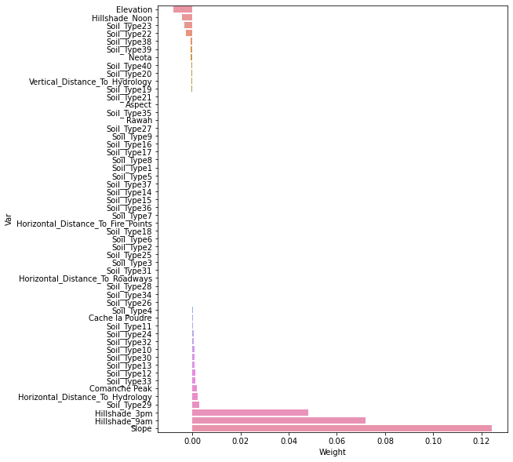

```python
logWeights = pd.Series(lr_clf.coef_[0], index = forestDF.columns)
logWeights = pd.DataFrame({'Var':logWeights.index, 'Weight':logWeights.values})
logWeights = logWeights.sort_values('Weight')
plt.figure(figsize=(8, 10))
sns.barplot(x='Weight', y = 'Var', data = logWeights);
```

The above weights are not scaled so we will reassess after scaling the predictors.

```python
sclObj = StandardScaler()
sclObj.fit(X)

XScaled = sclObj.transform(X)

lrs_clf = LogisticRegression(penalty='l2',
                             C=150.0,
                             class_weight=None)
iter_num = 0
for iter_num, (train_indices,test_indices) in enumerate(cv_Log.split(XScaled,Y)):
  lrs_clf.fit(XScaled[train_indices],Y[train_indices])
  y_hatS = lrs_clf.predict(XScaled[test_indices])
  print('****Iteration',iter_num,'****')
  print('Accuracy',mt.accuracy_score(Y[test_indices],y_hatS))
  print('Confusion Matrix \n',mt.confusion_matrix(Y[test_indices],y_hatS))
```

```
****Iteration 0 ****
Accuracy 0.7774591281341829
Confusion Matrix
 [[30383 11849]
 [10189 46608]]
****Iteration 1 ****
Accuracy 0.7741065748417131
Confusion Matrix
 [[30358 12060]
 [10310 46301]]
****Iteration 2 ****
Accuracy 0.7762675579880641
Confusion Matrix
 [[30581 11893]
 [10263 46292]]
****Iteration 3 ****
Accuracy 0.7765503034464651
Confusion Matrix
 [[30379 12027]
 [10101 46522]]
****Iteration 4 ****
Accuracy 0.7743893203001141
Confusion Matrix
 [[30211 12097]
 [10245 46476]]
****Iteration 5 ****
Accuracy 0.7749851053731736
Confusion Matrix
 [[30483 11953]
 [10330 46263]]
****Iteration 6 ****
Accuracy 0.7752678508315746
Confusion Matrix
 [[30444 11983]
 [10272 46330]]
****Iteration 7 ****
Accuracy 0.7779135404780417
Confusion Matrix
 [[30363 11951]
 [10042 46673]]
****Iteration 8 ****
Accuracy 0.7758737339567198
Confusion Matrix
 [[30243 12066]
 [10129 46591]]
****Iteration 9 ****
Accuracy 0.7754799099253754
Confusion Matrix
 [[30433 12061]
 [10173 46362]]
```

```python
accScaled = cross_val_score(lrs_clf, XScaled, Y, cv=cv_Log)
print('The mean accuracy was',np.mean(accScaled)*100,'% after',num_cv_iter,'cross validations.')
```

```
The mean accuracy was 77.58181946702481 % after 10 cross validations.
```

After scaling the predictors and changing the C hyperparameter to 150 the mean accuracy of our model after 10 cross validation iterations increased to 77.5%.

The high C hyperparameter value will give more weight to the training dataset. This indicates that the trainign data is more important.

Next we'll look at the weights of the predictors after the scaling.

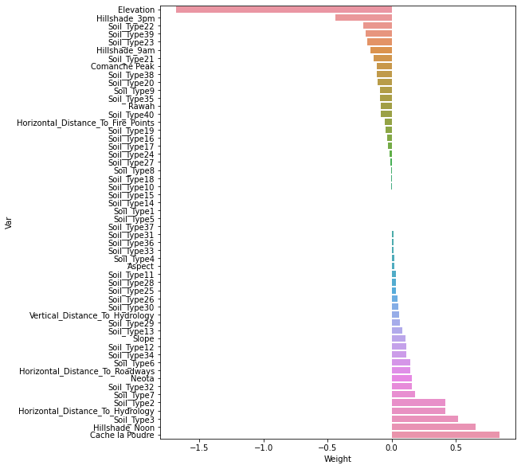

```python
logSWeights = pd.Series(lrs_clf.coef_[0],index=forestDF.columns)
logSWeights = pd.DataFrame({'Var':logSWeights.index,'Weight':logSWeights.values})
logSWeights = logSWeights.sort_values('Weight')
plt.figure(figsize=(8,10))
sns.barplot(x='Weight',y='Var',data=logSWeights);
```

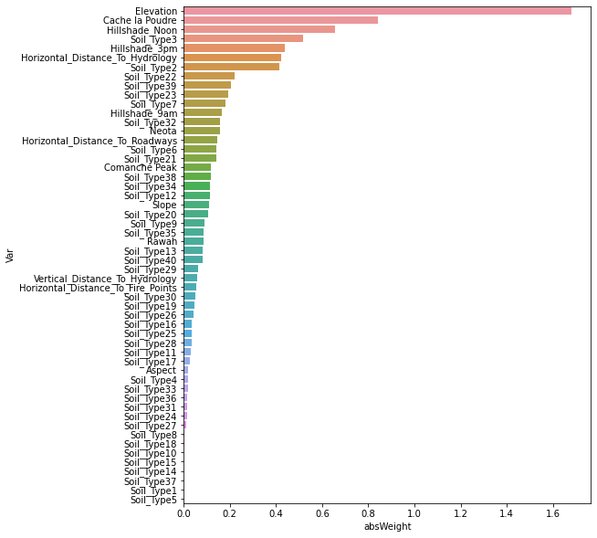

```python
logSWeights['absWeight'] = logSWeights['Weight'].abs()
logSWeights = logSWeights.sort_values('absWeight',ascending=False)
plt.figure(figsize=(8,10))
sns.barplot(x='absWeight',y='Var',data=logSWeights);
```

From the above plot, using Logistic Regression the four predictors that are weighted the highest after the data was scaled are Elevation, Cache la Poudre wilderness area, Hillshade_Noon, and Soil_Type3. This is cause to infer that these are the most important features for this model in predicting Pine or Spruce/Fir. More detail and explanation about these will be viewed later in the report.

# Testing a simpler model of Logistic Regression

We decided to leverage Random Forest to eliminate some of the variables included in the logistic regression model, to see if there is an increase in performance in a simpler model.

```python
# Feature Importance Graph
# Takes about five minutes
from sklearn.ensemble import RandomForestRegressor
rf = RandomForestRegressor(n_estimators = 50)
rf.fit(X, Y)
```

```
RandomForestRegressor(n_estimators=50)
```

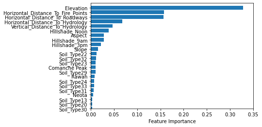

```python
sort = rf.feature_importances_.argsort()
plt.barh(forestDF.columns.values[sort], rf.feature_importances_[sort])
plt.xlabel('Feature Importance')
plt.axis([0, 0.35, 31, 54])
plt.show()
```

```python
forestDF_new = pd.DataFrame().assign(
                treeType=Y,
                Elevation=forestDF['Elevation'],
                Horizontal_Distance_To_Fire_Points=forestDF['Horizontal_Distance_To_Fire_Points'],
                Soil_Type22=forestDF['Soil_Type22'],
                Soil_Type32=forestDF['Soil_Type32'],
                Soil_Type23=forestDF['Soil_Type23'],
                Soil_Type29=forestDF['Soil_Type29'],
                Soil_Type24=forestDF['Soil_Type24'],
                Soil_Type33=forestDF['Soil_Type33'],
                Soil_Type31=forestDF['Soil_Type31'],
                Soil_Type13=forestDF['Soil_Type13'],
                Soil_Type20=forestDF['Soil_Type20'],
                Soil_Type30=forestDF['Soil_Type30'],
                Soil_Type3=forestDF['Soil_Type3'],
                Horizontal_Distance_To_Roadways=forestDF['Horizontal_Distance_To_Roadways'],
                Neota=forestDF['Neota'],
                Rawah=forestDF['Rawah'],
                ComanchePeak=forestDF['Comanche Peak'],
                Horizontal_Distance_To_Hydrology=forestDF['Horizontal_Distance_To_Hydrology'],
                Vertical_Distance_To_Hydrology=forestDF['Vertical_Distance_To_Hydrology'],
                Hillshade_Noon=forestDF['Hillshade_Noon'],
                Hillshade_9am=forestDF['Hillshade_9am'],
                Hillshade_3pm=forestDF['Hillshade_3pm'],
                Aspect=forestDF['Aspect'],
                Slope=forestDF['Slope']
                                                      )
```

Based on the importance output, we decided to build a logistic regression model with fewer variables:

```python
# Assign specific features to two different variables
if 'treeType' in forestDF:
    Y = forestDF_new['treeType'].values
    del forestDF_new['treeType']
    X = forestDF_new.values
```

```python
#Rerunning logistic regression on scaled values informed by the random forest importance output
sclObj = StandardScaler()
sclObj.fit(X)

XScaled = sclObj.transform(X)

# Re-creating logistic regression object
lr_clf_new = LogisticRegression(penalty='l2',
                             C=200.0,
                             class_weight=None)
iter_num = 0
for iter_num, (train_indices,test_indices) in enumerate(cv_Log.split(XScaled,Y)):
  lr_clf_new.fit(XScaled[train_indices],Y[train_indices])
  y_hatS = lr_clf_new.predict(XScaled[test_indices])
  print('****Iteration',iter_num,'****')
  print('Accuracy',mt.accuracy_score(Y[test_indices],y_hatS))
  print('Confusion Matrix \n',mt.confusion_matrix(Y[test_indices],y_hatS))
```

```
****Iteration 0 ****
Accuracy 0.7774288339779256
Confusion Matrix
 [[30513 11971]
 [10070 46475]]
****Iteration 1 ****
Accuracy 0.7766209898110654
Confusion Matrix
 [[30763 12051]
 [10070 46145]]
****Iteration 2 ****
Accuracy 0.7742883397792566
Confusion Matrix
 [[30250 11967]
 [10385 46427]]
****Iteration 3 ****
Accuracy 0.7764695190297791
Confusion Matrix
 [[30259 12086]
 [10050 46634]]
****Iteration 4 ****
Accuracy 0.77668157812358
Confusion Matrix
 [[30479 11917]
 [10198 46435]]
****Iteration 5 ****
Accuracy 0.7764897151339507
Confusion Matrix
 [[30290 11919]
 [10215 46605]]
****Iteration 6 ****
Accuracy 0.7762271657797211
Confusion Matrix
 [[30518 11959]
 [10201 46351]]
****Iteration 7 ****
Accuracy 0.7763988326651788
Confusion Matrix
 [[30537 11848]
 [10295 46349]]
****Iteration 8 ****
Accuracy 0.7763988326651788
Confusion Matrix
 [[30480 11934]
 [10209 46406]]
****Iteration 9 ****
Accuracy 0.7746114774460007
Confusion Matrix
 [[30338 11980]
 [10340 46371]]
```

```python
from sklearn.model_selection import cross_val_score
accScaled = cross_val_score(lr_clf_new, XScaled, Y, cv=cv_Log)
print('The mean accuracy was',np.mean(accScaled)*100,'% after',num_cv_iter,'cross validations.')
```

```
The mean accuracy was 77.54385079118238 % after 10 cross validations.
```

# SVM

## Creating Cross Validation Object - SVM

```python
cv_SGD = StratifiedShuffleSplit(n_splits=10,test_size=0.2)
```

## Creating SVM using SGD

```python
regularize_const = 0.1
iterations = 10

svm_sgd = SGDClassifier(alpha=regularize_const,
                        fit_intercept=True,
                        l1_ratio=0.0,
                        learning_rate='optimal',
                        loss='hinge',
                        max_iter=iterations,
                        n_jobs=1,
                        penalty='l2')
```

```python
scl = StandardScaler()

for train_idx, test_idx in cv_SGD.split(X,Y):
  svm_sgd.fit(scl.fit_transform(X[train_idx]),Y[train_idx])
  y_hatSVM = svm_sgd.predict(scl.transform(X[test_idx]))
  print('Accuracy:',mt.accuracy_score(Y[test_idx],y_hatSVM))
  print('Confusion Matrix \n',mt.confusion_matrix(Y[test_idx],y_hatSVM))
```

```
Accuracy: 0.7630391097557281
Confusion Matrix
 [[27612 14756]
 [ 8710 47951]]
Accuracy: 0.7628472467660988
Confusion Matrix
 [[27743 14625]
 [ 8860 47801]]
Accuracy: 0.7667955851316282
Confusion Matrix
 [[27903 14465]
 [ 8629 48032]]
Accuracy: 0.7666542124024276
Confusion Matrix
 [[27975 14393]
 [ 8715 47946]]
Accuracy: 0.7662199961627402
Confusion Matrix
 [[27797 14571]
 [ 8580 48081]]
Accuracy: 0.7647557786103061
Confusion Matrix
 [[27860 14508]
 [ 8788 47873]]
Accuracy: 0.7652606812145937
Confusion Matrix
 [[27973 14395]
 [ 8851 47810]]
Accuracy: 0.7648062688707349
Confusion Matrix
 [[27960 14408]
 [ 8883 47778]]
Accuracy: 0.7661190156418827
Confusion Matrix
 [[27872 14496]
 [ 8665 47996]]
Accuracy: 0.7645437195165052
Confusion Matrix
 [[27717 14651]
 [ 8666 47995]]
```

```python
accSVM = cross_val_score(svm_sgd, XScaled, Y, cv=cv_SGD)
print('The mean accuracy was',np.mean(accSVM)*100,'% after',num_cv_iter,'cross validations.')
```

```
The mean accuracy was 76.38792676892628 % after 10 cross validations.
```

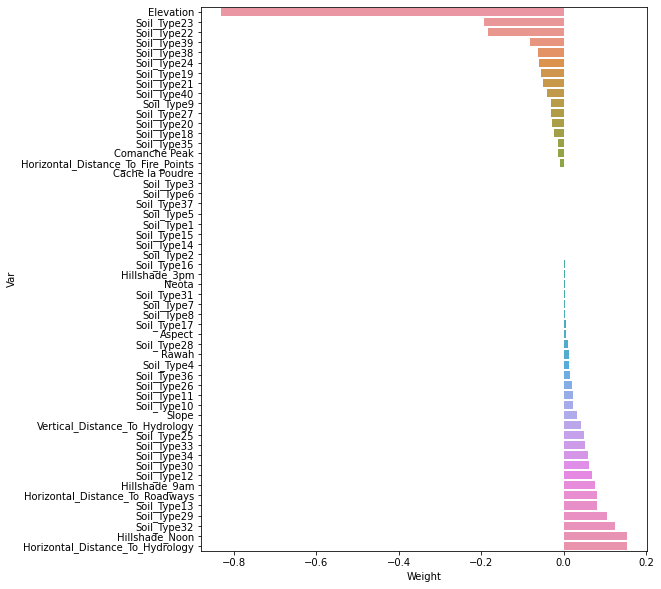

```python
SVMWeights = pd.Series(svm_sgd.coef_[0],index=forestDF.columns)
SVMWeights = pd.DataFrame({'Var':SVMWeights.index,'Weight':SVMWeights.values})
SVMWeights = SVMWeights.sort_values('Weight')
plt.figure(figsize=(8,10))
sns.barplot(x='Weight',y='Var',data=SVMWeights);
```

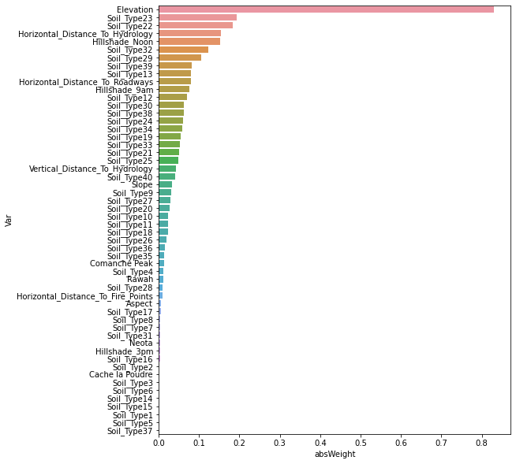

```python
SVMWeights['absWeight'] = SVMWeights['Weight'].abs()
SVMWeights = SVMWeights.sort_values('absWeight',ascending=False)
plt.figure(figsize=(8,10))
sns.barplot(x='absWeight',y='Var',data=SVMWeights);
```

From the above plot, using SVM the four predictors that are weighted the highest after the data was scaled are Elevation, Soil_Type23, Soil_Type22, and Horizontal_Distance_To_Hydrology. Once again, these features appear to be the most important in predicting for this particular model. More detail and explanation about these will be viewed later in the report.

The interpretability of Logistic Regression was fairly easy and understandable. This model also allowed for an easier way to see various accuracy scores for different train/test splits. We were able to create a loop that goes through different train/test splits and run logistic regression on each one to compare accuracy scores. This helps us to understand the average accuracy, due to the chance a specific train/test split gives an anomaly.

The SVM model provided a similar accuracy score, but ran significantly faster using Stochastic Gradient Descent. Manipulating the inputs of the model may have increased the accuracy above that of Logistic Regression. Using a smaller dataset to find the support vectors that are important and prioritizing those on the full dataset with SGD could increase performance.

Both models performed very well predicting on this dataset and ran quickly despite the large amount of data that we used.

```
                                   Var    Weight  absWeight
0                            Elevation -1.680369   1.680369
13                     Cache la Poudre  0.842795   0.842795
7                       Hillshade_Noon  0.655830   0.655830
16                          Soil_Type3  0.517072   0.517072
8                        Hillshade_3pm -0.438664   0.438664
3     Horizontal_Distance_To_Hydrology  0.421295   0.421295
15                          Soil_Type2  0.416653   0.416653
35                         Soil_Type22 -0.220209   0.220209
52                         Soil_Type39 -0.205023   0.205023
36                         Soil_Type23 -0.191861   0.191861
20                          Soil_Type7  0.183463   0.183463
6                        Hillshade_9am -0.165084   0.165084
45                         Soil_Type32  0.159486   0.159486
11                               Neota  0.157047   0.157047
```

[output cut: 40 more lines]

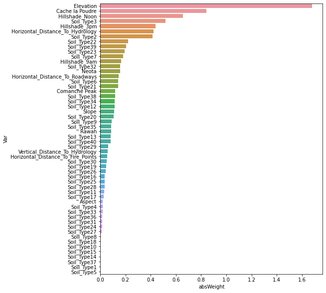

```python
print(logSWeights)
plt.figure(figsize=(8,10))
sns.barplot(x='absWeight',y='Var',data=logSWeights);
```

```python
plt.figure(figsize = (16, 8))
sns.countplot(data = forest_cover_type,
              x = 'Soil_Type',
              hue = 'Cover_Type')
plt.xticks(rotation = 90)
plt.show()
```

[output not shown]

## Looking at weights of the model

The weights from the logistic regression model help us identify the importance of the various features. Having so many differnet features, it can be nice to see which ones impact the classification more so than others. This way, we can use those of utomst importance to create a better/more accurate model.

We can see from the graph these weights for the various features quite nicely. The graph shows us that 'Elevation' has the largest absolute value. This allows us to assume that it plays the largest role in classification, in regard to all the other features in this dataset. Cache la Poudre is the next highest value.

We believe that certain features have higher weights due to their immediate connection with the classification. The Spruce/Fir trees grow best in certain conditions; some of these conditions are listed in the features:

- Elevation is a key driver in identifying whether a tree is a Spruce/Fir.
- Of the soil types listed in the model: Soil_Type3 is described as Haploborolis - Rock outcrop complex, rubbly, which is associated with higher elevations.

Also, if not it seems that many of the soil types, as well as the aspect of the land plot, have little importance in predicting between these two cover types. This could be because both of these trees either grow equally well or poorly in these soil types. In terms of the aspect, this predictor could be confounded with the different hillshade values as they are all four directly related to the amount of sunlight a plot of land gets.

# Support Vector Interpretation

```python
# Sub-sampling data and verifying still balanced
forestSubDF = forestFullDF.sample(10000)
forestSubDF.groupby('treeType').count()
```

| treeType | Elevation | Aspect | Slope | Horizontal_Distance_To_Hydrology | Vertical_Distance_To_Hydrology | Horizontal_Distance_To_Roadways | Hillshade_9am | Hillshade_Noon | Hillshade_3pm | Horizontal_Distance_To_Fire_Points | Rawah | Neota | Comanche Peak | Cache la Poudre | Soil_Type1 | Soil_Type2 | Soil_Type3 | Soil_Type4 | Soil_Type5 | Soil_Type6 | Soil_Type7 | Soil_Type8 | Soil_Type9 | Soil_Type10 | Soil_Type11 | Soil_Type12 | Soil_Type13 | Soil_Type14 | Soil_Type15 | … |
| --- | --- | --- | --- | --- | --- | --- | --- | --- | --- | --- | --- | --- | --- | --- | --- | --- | --- | --- | --- | --- | --- | --- | --- | --- | --- | --- | --- | --- | --- | --- |
| 0 | 4167 | 4167 | 4167 | 4167 | 4167 | 4167 | 4167 | 4167 | 4167 | 4167 | 4167 | 4167 | 4167 | 4167 | 4167 | 4167 | 4167 | 4167 | 4167 | 4167 | 4167 | 4167 | 4167 | 4167 | 4167 | 4167 | 4167 | 4167 | 4167 | … |
| 1 | 5833 | 5833 | 5833 | 5833 | 5833 | 5833 | 5833 | 5833 | 5833 | 5833 | 5833 | 5833 | 5833 | 5833 | 5833 | 5833 | 5833 | 5833 | 5833 | 5833 | 5833 | 5833 | 5833 | 5833 | 5833 | 5833 | 5833 | 5833 | 5833 | … |

```python
# Creating and Running SVM model on smaller dataframe
if 'treeType' in forestSubDF:
    ySub = forestSubDF['treeType'].values
    del forestSubDF['treeType']
    xSub = forestSubDF.values
```

```python
num_cv_iter = 10
num_instances = len(Y)
cv_Log = ShuffleSplit(n_splits = num_cv_iter, test_size = 0.2)
```

```python
for train_indices, test_indices in cv_Log.split(xSub, ySub):
    X_train = xSub[train_indices]
    Y_train = ySub[train_indices]
    X_test = xSub[test_indices]
    Y_test = ySub[test_indices]
X_train_scaled = sclObj.transform(X_train)
X_test_scaled = sclObj.transform(X_test)
```

```python
svm_clf = SVC(C = 0.5,
             kernel = 'rbf',
             degree = 3,
             gamma = 'auto')
```

```python
# Results
svm_clf.fit(X_train_scaled,Y_train)
y_hatSVM = svm_clf.predict(X_test_scaled)
print('Accuracy', mt.accuracy_score(Y_test, y_hatSVM))
print('Confusion Matrix \n', mt.confusion_matrix(Y_test, y_hatSVM))
```

```
Accuracy 0.7905
Confusion Matrix
 [[ 573  246]
 [ 173 1008]]
```

```python
# Support Vector shape:
print(svm_clf.support_vectors_.shape)
print(svm_clf.support_.shape)
print(svm_clf.n_support_)
```

```
(4399, 54)
(4399,)
[2183 2216]
```

```python
forestTested = forestSubDF.iloc[train_indices]
forestSupport = forestTested.iloc[svm_clf.support_,:]
forestSupport['treeType'] = ySub[svm_clf.support_]
forestSubDF['treeType'] = ySub
```

[figure not shown]

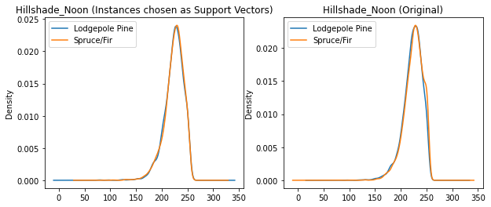

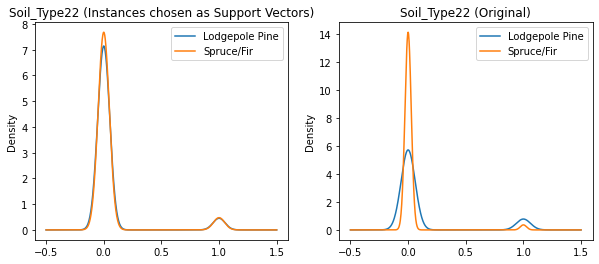

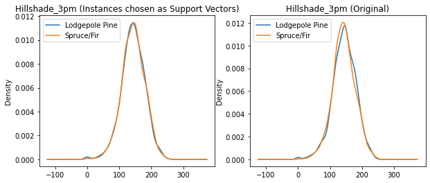

```python
forestGroupSupport = forestSupport.groupby(['treeType'])
forestGroup = forestSubDF.groupby(['treeType'])

vars_to_plot = ['Elevation', 'Hillshade_Noon', 'Soil_Type22', 'Hillshade_3pm']

for v in vars_to_plot:
    plt.figure(figsize = (10, 4))
    plt.subplot(1, 2, 1)
    ax = forestGroupSupport[v].plot.kde()
    plt.legend(['Lodgepole Pine', 'Spruce/Fir'])
    plt.title(v + ' (Instances chosen as Support Vectors)')

    plt.subplot(1,2,2)
    ax = forestGroup[v].plot.kde()
    plt.legend(['Lodgepole Pine', 'Spruce/Fir'])
    plt.title(v + ' (Original)')
```

## Interpret Support Vectors

[figure not shown]

```python
sns.set(rc={'figure.figsize':(24.7,5.27)})

#side by side plot
fig, ax =plt.subplots(1,2)

# box plots for elevation vs cover type
sns.boxplot(x = 'Cover_Type', y = 'Elevation', data = forestDF, ax=ax[0], palette=["m", "g", "b", "c", "r", "w", "m"])

# count plot for cover type
sns.boxplot(x = 'Cover_Type', y = 'Hillshade_Noon', data = forestDF, ax=ax[1], palette=["m", "g", "b", "c", "r", "w", "m"])

fig.show()
```

Soil type 22 (Leighcan family, till substratum, extremely bouldery) is a soil type associated with high slope (mountainous) terrain.

While Spruce/Fir is described as a tree type that does well in the 9,500-11,500 feet.

High Elevation Forests are 5% of Colorado's landscape (source: https://cnhp.colostate.edu/cnhpblog/2010/08/10/ecological-systems-spruce-fir-forests/)